# Average Company Age

peter.laudenslager@gmail.com

October 26, 2014

Model the average age of companies based on random product substitution.

see: http://blog.gardeviance.org/2014/10/of-peace-war-and-wonder-vs-company-age.html

## Parameters

```r
# setup the environment
setwd = "~/Projects/CompanyAgeSimulation"
set.seed = 1024

# set starting parameters
starting_average_age = 45
starting_standard_deviation_age = 10
number_of_companies = 1000

# set simulation parameters
product_substitution_rate = .03
age_of_disruptor = 12
years_of_competition = 150
```

## Initialize companies

```r
# create companies
companies <- round(rnorm(number_of_companies,
                         mean=starting_average_age,
                         sd=starting_standard_deviation_age
                         ),
                   digits=1)

# check company ages by plotting
summary(companies)
```

```
##    Min. 1st Qu.  Median    Mean 3rd Qu.    Max.
##   12.60   39.15   45.30   45.56   52.40   78.80
```

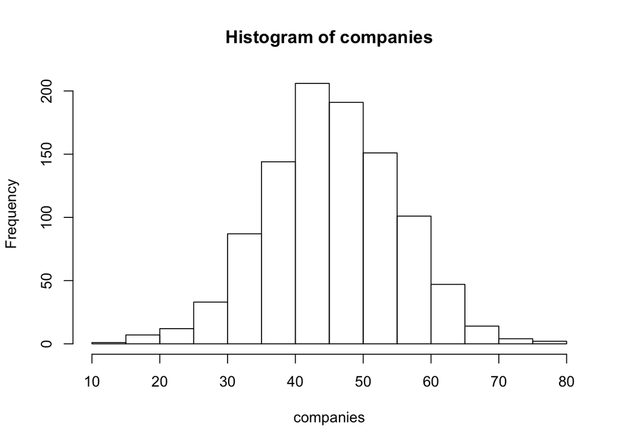

```r
hist(companies)
```

## Simulation functions

```r
# Function to return a new set of company ages after 1 year of competition
compete <- function(age_vector, substitution_rate){
  # Pick companies to be replaced by new entrants
  targets <- round(runif(substitution_rate*length(age_vector),
                         min=1, max=length(age_vector)
                         )
                   )

  # Age all companies by 1 year
  age_vector <- age_vector + 1

  # Replace target companies with new entrants
  age_vector[targets] <- age_of_disruptor
  return(age_vector)
  }

# simulate new companies entering and competing
substitute <- function(age_vector, run_years, substitution_rate){
  ages_all <- 0
  for(i in 1:run_years){
    age_vector <- compete(age_vector,substitution_rate)
    ages_all[i] = mean(age_vector)
    }
  return(ages_all)
  }

# plot function
plot_by_year <- function(avg_by_yr,min_by_yr,max_by_yr){
  # plot a graph with age on the x axis, and low, mean, and high results
  subtitle = paste0(c('sim. runs=',max(sim_range),
                      ', companies=',number_of_companies,
                      ', sub. rate=',product_substitution_rate,
                      ', new entrant age=',age_of_disruptor),
                    collapse="")
  plot(1:years_of_competition,avg_by_yr,
       type='l',
       ylim=c(0,50),
       col='blue',
       main='Average age of all companies with competition',
       sub=subtitle,
       xlab='years of competition',
       ylab='company age'
       )
  lines(1:years_of_competition,max_by_yr, col='red')
  lines(1:years_of_competition,min_by_yr, col='green')
  }
```

## The competition function

The competition function simply assumes that some percentage of existing companies will be replaced by new companies.

This is problematic for several reasons, but the first is that we have no idea of company size, so we cannot choose the top 400 companies for our average.

Assuming that companies are ranked by revenue, we need to estimate revenue for the companies, and since some old companies are being replaced by young companies, presumably the young company has smaller revenue. We also should assume that the young company has a high revenue growth rate, for a while, at least. The (possibly large) company that is being replaced by a younger competitor will presumably experience negative growth for several years, rather than just being suddenly replaced.

The model should acknowledge that the largest companies will tend to be older, because they have had time to grow. A company growing at 100% per year requires 6.6 years to go from $10M to $1B. It also seems like a company’s revenue should follow something more like an S curve.

In the current model, companies get randomly selected to be replaced by a company of a specified age.

## Wardley’s model

Simon’s model assumes a 3% substitution rate. If 1000 companies start with an average age of 45, and age by 1 year each year, then with no substitution, the average age also goes up by 1 year each year. The average at the end of the year is 46 * 1000 / 1000 = 46.

3% substitution means 30 companies get replaced with a younger company. If the younger company is 1 year old, then the new average is (46 * 970 + 1 * 30) / 1000 = 44.65. To make my simulation produce a constant age, I had to choose a younger company age of 12. After 1 year, the average age is (46 * 970 + 12 * 30) / 1000 = 44.98.

## Simulate ages over multiple trials

```r
# run the analysis many times with standard parameters to check stability

# return the ages vector
sim <- function(x){
  ages = substitute(companies, years_of_competition, product_substitution_rate)
  return(ages)
  }

# function to return parameters over the year / sim run matrix
# returns summary table (min, max, average, others) of all sim runs, one summary per year
summarize_by_year <- function(year){
  return(summary(data[year,]))
}

sim_range=1:100

# Return many versions of the ages vector
# elements in data[i,j] are i years and j simulation runs
data=(sapply(sim_range,sim))
params_by_year = sapply(1:years_of_competition,summarize_by_year)
dim(params_by_year)
```

```
## [1]   6 150
```

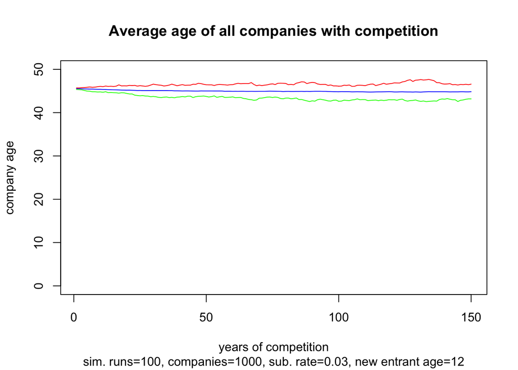

```r
avg_by_year <- params_by_year['Mean',]
max_by_year <- params_by_year['Max.',]
min_by_year <- params_by_year['Min.',]


# plot a graph with age on the x axis, and low, mean, and high results
plot_by_year(avg_by_year,min_by_year,max_by_year)
```

```r
# subtitle = paste0(c('sim. runs=',max(sim_range),
#                     ', companies=',number_of_companies,
#                     ', sub. rate=',product_substitution_rate,
#                     ', new entrant age=',age_of_disruptor),
#                   collapse="")
# plot(1:years_of_competition,avg_by_year,
#      type='l',
#      ylim=c(0,50),
#      col='blue',
#      main='Average age of all companies with competition',
#      sub=subtitle,
#      xlab='years of competition',
#      ylab='company age'
#      )
# lines(1:years_of_competition,max_by_year, col='red')
# lines(1:years_of_competition,min_by_year, col='green')
```

# Sensitivity test other parameters